# Resistant hypertension

**Libraries**

```r
library(tidyverse)
library(survival)   # survival analysis
library(data.table) # fread() function
library(gridExtra)  # plots to grid
library(survminer)  # ggbased visualization and extra diagnostics
library(visdat)     # visualization of tibble and na's
library(kableExtra) # Pretty tables
library(tableone)   # Characteristics table
library(compareC)   # Compare c-index

#install.packages("scripts/packages/warp_0.2.0.tar.gz", repos=NULL)
#install.packages("scripts/packages/slider_0.2.1.tar.gz", repos=NULL)
#install.packages("scripts/packages/slider_0.3.0.tar.gz", repos=NULL)
#install.packages("scripts/packages/tinytest_1.2.4.tar.gz", repos=NULL)
#install.packages("scripts/packages/stringdist_0.9.6.3.tar.gz", repos=NULL)
#install.packages("scripts/packages/geosphere_1.5-10.tar.gz", repos=NULL)
#install.packages("scripts/packages/fuzzyjoin_0.1.6.tar.gz", repos=NULL)
library(slider)
library(fuzzyjoin)

#Trying to fix survminer problems...
#install.packages("scripts/packages/ggplot2_3.4.0.tar.gz", repos=NULL)
#install.packages("scripts/packages/survminer_0.4.9.tar.gz", repos=NULL)


fg_path <- "/finngen/library-red/finngen_R8/"
data_path <- "data"
fig_path <- "figs.diursubcl"
font_size <- 12

source("scripts/functions.R")
```

# 1 Data

## 1.1 Definitions

**Included ATC codes:**

- C02
  - Include all, except C02KX
  - Two medicines: Group C02L
- C03
  - Include all.
  - Two medicines: C03E
- C07
  - Include all.
  - Two medicines: Groups C07B, C07C, C07D, C07FB
- C08
  - Include all.
  - Two medicines: Group C08G
- C09
  - Include all.
  - Two medicines: C09BA, C09BB, C09BX02, C09BX05, C09DA, C09DB, C09DX02, C09DX04, C09DX05, C09XA52
  - Three medicines: C09BX01, C09BX03, C09BX04, C09DX01, C09DX03, C09DX06, C09DX07, C09XA54

**Drug classes:**

- Diuretics
- ACE inhibitors (ACEI)
- Angiotensin II receptor blockers (ARB)
- Calcium chanel blockers (CCB)
- Beta blockers (BB)
- Other

**Datasets**

- Count variable NRMED_HT
  - Maximum number of different antihypertensive *medicines* within 3 months window
  - Only persons with diagnosed hypertension I9_HYPTENS and > 0 medicines
- Count variable NRCL_HT
  - Maximum number of different antihypertensive medicine *classes* within 3 months window
  - Only persons with diagnosed hypertension I9_HYPTENS and > 0 medicines
- Binary variable RES_HT
  - Cases: 4-5 drug classes within 3 months time window *and* I9_HYPTENS.
  - Controls: 1 drug purchase and I9_HYPTENS.
- Binary variable REFR_HT
  - Cases: $\geq$ 6 drug classes within 3 months time window *and* I9_HYPTENS.
  - Controls: 1 drug purchase and I9_HYPTENS.

## 1.2 Create variables NRMED_MAX and NRCLASS_MAX

**Copy and preprocess outside the R**

Endpoint file is transfered and unzipped. Entries of interest are selected from endpoint file prior to import to R, because the original phenotype file is very large.

Pattern: grep ‘PURCH’ | grep ’ C0[2,3,7,8,9]’

```bash
phenodir="/finngen/red/phenotype-R8"
datadir="/finngen/red/res_ht/data"
grep 'PURCH\|FINNGENID'  $phenodir/finngen_R8_detailed_longitudinal.txt | grep '\sC0[2,3,7,8,9]\|FINNGENID'  > $datadir/R8_detailed_C0.txt &
```

**Moving sum of drug purchases**

First we calculate moving sum for drug purchases within the 3 months window. Then we create file for cases in ‘endpoint format’.

Searching unique medicines and handling strings in each window is slow, so this is run as a separate Rscript.

```bash
Rscript scripts/gen_res_ht_pre55_diursubcl.R &
```

## 1.3 Read files and create final variables

Endpoint and covariate files are transfered and unzipped. Entries of interest are selected from endpoint file prior to import to R, because the original phenotype file is very large.

```bash
#Self written perl-script to extract columns from phenotype file
datadir="/home/ivm/res_ht/data"
perl scripts/select_columns.pl $datadir/finngen_R8_endpoint.txt  $datadir/finngen_R8_HT.txt scripts/fg_pheno_cols.txt &
```

## 1.4 Combine and preprocess

Define variables

```r
names_ep <- list("CVD_HARD", "CHD","HEARTFAIL", "STR_EXH", "INTRACRA",  "RENFAIL", "DEATH", "K_CARDIAC")
names_ep_post <- lapply(names_ep, function(ep){str_glue("{ep}_POST")})
nice_names <- list(CVD_HARD = "CVD", STR = "Stroke", STR_EXH = "Ischaemic stroke", INTRACRA = "Hemorrhagic stroke", CHD="CHD", HEARTFAIL = "Heart Failure", DEMENTIA = "Dementia", RENFAIL = "Renal Failure", DEATH = "Death", K_CARDIAC = "Cardiac death")

covs <- c("female", "DIABETES", "OBESITY", "HYPCHOL_WIDE") #used for cox
covs_nfem <- c("DIABETES", "OBESITY", "HYPCHOL_WIDE")
covs_pre <- c("female", "DIABETES_PRE", "OBESITY_PRE", "HYPCHOL_WIDE_PRE")
```

Read in new file and combine with other data.

```r
#endpoints and covariates
phenotypes <- fread(str_glue("{data_path}/finngen_R8_HT.txt"))
#endpoints and covariates
htres_pre55 <- fread(str_glue("{data_path}/nrmed_max_r8_pre55_diursubcl.tsv"))
htres_pre55_long <- fread(str_glue("{data_path}/nrmed_long_r8_pre55_diursubcl.tsv.gz"))
phenomin <- fread(str_glue("{fg_path}/phenotype_2.0/data/finngen_R8_minimum.txt.gz"))
sex_in <- fread(str_glue("{fg_path}/analysis_covariates/finngen_R8_cov_1.0.txt.gz")) %>%
  select(FINNGENID, SEX_IMPUTED)
#summary(htres_pre55)

#HT_RES_CL was originally created in script gen_res_ht.R as moving sum, and not here, because that's only way to get age and year correct. For example in case where nrcl_max == 6, we should use age when nrcl_max==4 is first time reached, not when maximum is reached.

df.55 <- phenomin %>%
  right_join(sex_in, by = "FINNGENID") %>%
  left_join(htres_pre55, by = "FINNGENID") %>%
  left_join(phenotypes, by = "FINNGENID") %>%

  #change variable names
  rename(NRCLASS_MAX55 =  NRCLASS_MAX, NRCLASS_MAX55_AGE = NRCLASS_MAX_AGE, NRCLASS_MAX55_YEAR =  NRCLASS_MAX_YEAR) %>%

  mutate(
         female = SEX_IMPUTED,

         #These include all values, also if I9_HYPTENS == 0; for NRMED_MAX NA's are set as 0.
         NRCLASS_MAX55 = if_else(is.na(NRCLASS_MAX55), 0L, NRCLASS_MAX55),
         NRCLASS_MAX55_AGE = if_else(NRCLASS_MAX55 == 0, NA_real_, NRCLASS_MAX55_AGE),
         NRCLASS_MAX55_YEAR = if_else(NRCLASS_MAX55 == 0, NA_integer_, NRCLASS_MAX55_YEAR),

         #These include only values where I9_HYPTENS == 1 and NRMED_MAX55 > 0, rest are set as NA
         NRCL_HT55 = if_else(I9_HYPTENS == 1 & NRCLASS_MAX55 > 0, NRCLASS_MAX55, NA_integer_),
         NRCL_HT55_AGE = if_else(I9_HYPTENS == 1, NRCLASS_MAX55_AGE, NA_real_),
         NRCL_HT55_YEAR = if_else(I9_HYPTENS == 1, NRCLASS_MAX55_YEAR, NA_integer_),
         NRCL5_HT55  = if_else(NRCL_HT55  >= 5, "5+", as.character(NRCL_HT55)),
         NRCL4_HT55  = if_else(NRCL_HT55  >= 4, "4+", as.character(NRCL_HT55)),
         NRCL5_HT55_AGE  = NRCL_HT55_AGE,
         NRCL4_HT55_AGE  = NRCL_HT55_AGE,

         #Two class variable from variables above
         RES2_HT55 = case_when(
           NRCLASS_MAX55 == 1 & I9_HYPTENS == 1 ~ "Mild",
           NRCLASS_MAX55 >= 4 & I9_HYPTENS == 1 ~ "Resistant",
           TRUE ~ NA_character_
         ) %>% factor(levels=c("Mild","Resistant")),

         #Wider definition of hypercholesterolaemia, includes also statin medication
         HYPCHOL_WIDE = if_else(E4_HYPERCHOL == 1 | RX_STATIN ==1, 1, 0)) %>%

  rowwise() %>%
  mutate(HYPCHOL_WIDE_AGE = min(E4_HYPERCHOL_AGE,RX_STATIN_AGE)) %>%
  ungroup() %>%
  relocate(c(contains("I9_"),contains("RX_")), .after = last_col()) %>%
  rename_at(vars(contains('I9_')), list(~str_remove(., "I9_"))) %>%
  rename_at(vars(contains('RX_')), list(~str_remove(., "RX_"))) %>%
  rename_at(vars(contains('E4_')), list(~str_remove(., "E4_"))) %>%
  rename_at(vars(contains('N14_')), list(~str_remove(., "N14_"))) %>%
  rename_at(vars(contains('F5_')), list(~str_remove(., "F5_")))  %>%

  #NA's in disease covariates set as 0. These NA's represent similar variables,
  #are present for GWASes and are not relevant for us.
  mutate_at(c( "DIABETES", "OBESITY", "HYPCHOL_WIDE"), as.integer) %>%
  mutate_at(c( "DIABETES", "OBESITY", "HYPCHOL_WIDE"), ~if_else(is.na(.), 0L, .))
```

**Plot count the new count variables**

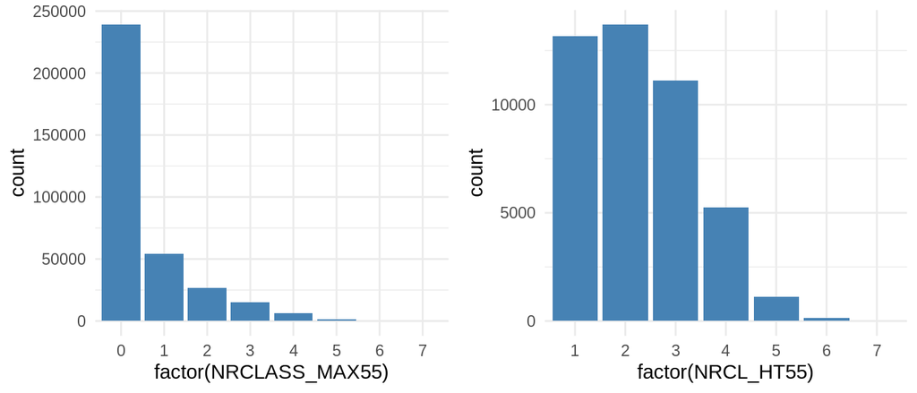

```r
p1 <- ggplot(df.55, aes(x=factor(NRCLASS_MAX55)))+
  geom_bar(stat="count",  fill="steelblue") +
  theme_minimal() +
  scale_x_discrete(na.translate = FALSE)


p2 <- ggplot(df.55, aes(x=factor(NRCL_HT55)))+
  geom_bar(stat="count",  fill="steelblue") +
  theme_minimal() +
  scale_x_discrete(na.translate = FALSE)

ggarrange(p1,p2)
```

```r
table(df.55$NRCL_HT55)
```

```
##
##     1     2     3     4     5     6     7
## 13165 13692 11114  5265  1119   143     7
```

**Outcomes before AGE 55 and covariates after AGE 55 removed**

```r
#Drug purchase registry starts at 1994 - let's remove outcome event's before that.

df.55 <- df.55 %>%
  filter(!is.na(FU_END_AGE) & FU_END_AGE >= 0) %>% #Now removed (at earlier step just set as NA)

  mutate(across(all_of(unlist(names_ep)), #Outcome events before YEAR 1994 set as NA
                ~if_else(!is.na(get(str_glue("{cur_column()}_YEAR"))) &  get(str_glue("{cur_column()}_YEAR")) < 1994,
                         NA_integer_, .) ),

         across(all_of(unlist(names_ep)), #Outcome events before AGE 55 set as NA -> new variable {outcome}_POST
                list(POST=~if_else(get(str_glue("{cur_column()}_AGE")) < 55,
                                   NA_integer_, .) )),


         across(all_of(covs_nfem), #Covariates _after_ AGE 55 set as NA -> new variable {cov}_PRE
                list(PRE=~if_else( get(str_glue("{cur_column()}_AGE")) >= 55, 0L, as.integer(.)) ))

  )%>%
  mutate_at("NRCL_HT55", as.factor)


#         across(all_of(unlist(names_ep)), #If {outcome}_POST is NA, also corresponding AGE variable is set as NA
 #               list(POST_AGE =~if_else(    is.na(get(str_glue("{cur_column()}_POST"))),
  #                                     NA_real_, get(str_glue("{cur_column()}_AGE")) ))),


#Each outcome is filtered separately - for cox-model
# df.55.list <- lapply(names_ep, function(ep){

#      df.55 %>% filter(get(str_glue("{ep}_AGE")) >=55)

#  }) %>% setNames(names_ep)


#Filter if no hypertension, no medication or age above 55
df.55.all <- df.55
df.55 <- df.55 %>% filter(!is.na(NRCL_HT55))
```

**Summaries for outcomes**

```r
lapply(names_ep, function(ep){
    df.55 %>%
       select(str_glue("{ep}_AGE"), ep, str_glue("{ep}_POST"))  %>%
       mutate_at(c(ep, str_glue("{ep}_POST")), as.factor) %>%
       summary()
  }) %>% setNames(names_ep)
```

```
## $CVD_HARD
##   CVD_HARD_AGE   CVD_HARD     CVD_HARD_POST
##  Min.   : 0.15   0   :34207   0   :26656
##  1st Qu.:54.50   1   : 9857   1   : 6054
##  Median :62.38   NA's:  441   NA's:11795
##  Mean   :61.18
##  3rd Qu.:69.26
##  Max.   :82.82
##
## $CHD
##     CHD_AGE        CHD        CHD_POST
##  Min.   : 0.15   0   :37077   0   :29156
##  1st Qu.:55.17   1   : 7128   1   : 4438
##  Median :62.98   NA's:  300   NA's:10911
##  Mean   :61.76
##  3rd Qu.:69.75
##  Max.   :82.82
##
## $HEARTFAIL
##  HEARTFAIL_AGE   HEARTFAIL    HEARTFAIL_POST
##  Min.   : 0.01   0   :40323   0   :32220
##  1st Qu.:56.36   1   : 4048   1   : 2682
##  Median :63.91   NA's:  134   NA's: 9603
##  Mean   :62.52
##  3rd Qu.:70.46
##  Max.   :82.03
##
## $STR_EXH
##   STR_EXH_AGE    STR_EXH      STR_EXH_POST
##  Min.   : 0.63   0   :38774   0   :30842
##  1st Qu.:56.52   1   : 3448   1   : 2302
##  Median :64.12   NA's: 2283   NA's:11361
##  Mean   :62.69
##  3rd Qu.:70.59
##  Max.   :82.81
##
## $INTRACRA
##   INTRACRA_AGE   INTRACRA     INTRACRA_POST
##  Min.   : 2.46   0   :39014   0   :31134
##  1st Qu.:56.98   1   :  885   1   :  494
```

[output cut: 16 more lines]

```
##  Min.   : 2.46   0:41984   0   :33760
##  1st Qu.:57.30   1: 2521   1   : 2202
##  Median :64.75             NA's: 8543
##  Mean   :63.33
##  3rd Qu.:71.11
##  Max.   :81.94
##
## $K_CARDIAC
##  K_CARDIAC_AGE   K_CARDIAC K_CARDIAC_POST
##  Min.   : 2.46   0:43315   0   :34918
##  1st Qu.:57.30   1: 1190   1   : 1044
##  Median :64.75             NA's: 8543
##  Mean   :63.33
##  3rd Qu.:71.11
##  Max.   :81.94
```

## 1.5 Characteristics

**Number of drug classes**

```r
htres_pre55_long %>%
  #slice(1:10000) %>%
  select(FINNGENID, sum_nr_class, sum_classes) %>%
  #Highest number of classes selected
  group_by(FINNGENID) %>%
    slice(which.max(sum_nr_class)) %>%
  ungroup()  %>%
  #sum_classes converted to vector and arranged alphabetically
  mutate(sum_classes = str_split(sum_classes,"\\|"),
         sum_classes = lapply(sum_classes, sort)) %>%
  #Grouped by sum_clases and number of each combination selected
  group_by(sum_classes) %>%
    summarise(n=n()) %>%
  ungroup %>%
  #Pecentage calculated
  mutate(perc=round(n/sum(n)*100,2)) %>%
  #Format changes and ordering
  rowwise %>%
    mutate(sum_classes =  glue::glue_collapse(sum_classes, sep=", ")) %>%
  ungroup() %>%
  arrange(desc(n)) %>%
  rename(class_combinations = sum_classes) %>%
  filter(n>=5) %>%
  my.kable() %>%
  kable_styling(font_size = 12, full_width=F, position="left")
```

| class_combinations | n | perc |
| --- | --- | --- |
| BB | 36492 | 32.74 |
| ARB | 7190 | 6.45 |
| ACEI | 6114 | 5.48 |
| diuretic_K, diuretic_T | 4999 | 4.48 |
| CCB | 4831 | 4.33 |
| ACEI, BB | 4058 | 3.64 |
| BB, CCB | 3716 | 3.33 |
| ARB, BB | 3525 | 3.16 |
| ARB, diuretic_T | 3046 | 2.73 |
| BB, diuretic_K, diuretic_T | 2402 | 2.15 |
| ACEI, diuretic_T | 2293 | 2.06 |
| ACEI, CCB | 2061 | 1.85 |
| ARB, CCB, diuretic_T | 2006 | 1.80 |
| ARB, CCB | 1987 | 1.78 |
| ARB, BB, diuretic_T | 1887 | 1.69 |
| ACEI, BB, CCB | 1765 | 1.58 |
| ARB, BB, CCB, diuretic_T | 1674 | 1.50 |
| ACEI, ARB | 1553 | 1.39 |
| ACEI, BB, diuretic_T | 1535 | 1.38 |
| ACEI, BB, CCB, diuretic_T | 1344 | 1.21 |
| ARB, BB, CCB | 1305 | 1.17 |
| ACEI, CCB, diuretic_T | 1175 | 1.05 |
| BB, diuretic_T | 1069 | 0.96 |
| diuretic_K | 871 | 0.78 |
| ACEI, diuretic_K, diuretic_T | 839 | 0.75 |
| BB, CCB, diuretic_K, diuretic_T | 767 | 0.69 |
| ACEI, ARB, diuretic_T | 737 | 0.66 |
| diuretic_T | 710 | 0.64 |
| ACEI, BB, diuretic_K, diuretic_T | 627 | 0.56 |
| CCB, diuretic_K, diuretic_T | 626 | 0.56 |

[output cut: 78 more lines]

```r
#One line removed, because n<5.
```

**Number of individuals** Here hypertensive individuals have hypertension diagnosis, at least one medication and no history of outcome before age 55.

```r
font_size <- 12

#Hypertension
df.55.all %>%
  mutate(HT_TMP = if_else(is.na(NRCL_HT55) | as.numeric(NRCL_HT55) == 0, 0L, 1L)) %>%
  summarise(n=n(), ht_n = sum(HT_TMP, na.rm=T), ht_p = round(mean(HT_TMP, na.rm=T)*100,2))%>%
  my.kable() %>%
  kable_styling(font_size = font_size, full_width=F, position="left")
```

| n | ht_n | ht_p |
| --- | --- | --- |
| 342499 | 44505 | 12.99 |

### 1.5.1 Number of medicine classes

```r
#Number of medicine classes
df.55 %>%
  create_n_table("NRCL5_HT55", covs_pre, names_ep_post) %>%
  mutate_all(~str_replace(.,"^[0-4]\\s.*$", "-")) %>%
  my.kable() %>%   kable_styling(font_size = font_size)
```

| NRCL5_HT55 | 1 | 2 | 3 | 4 | 5+ | P-value |
| --- | --- | --- | --- | --- | --- | --- |
| n | 13165 | 13692 | 11114 | 5265 | 1269 | NA |
| female | 6792 (51.6%) | 7388 (54%) | 6096 (54.8%) | 2602 (49.4%) | 545 (42.9%) | <2e-16 |
| DIABETES_PRE | 1883 (14.3%) | 2677 (19.6%) | 2779 (25%) | 1796 (34.1%) | 580 (45.7%) | <2e-16 |
| OBESITY_PRE | 611 (4.6%) | 1089 (8%) | 1203 (10.8%) | 808 (15.3%) | 231 (18.2%) | <2e-16 |
| HYPCHOL_WIDE_PRE | 3104 (23.6%) | 4466 (32.6%) | 4463 (40.2%) | 2539 (48.2%) | 752 (59.3%) | <2e-16 |
| CVD_HARD_POST | 2427 (22.7%) | 1651 (16.5%) | 1307 (16.7%) | 551 (15.9%) | 118 (16.3%) | <2e-16 |
| CHD_POST | 1800 (16.5%) | 1208 (11.8%) | 922 (11.4%) | 412 (11.5%) | 96 (12.5%) | <2e-16 |
| HEARTFAIL_POST | 1067 (9.4%) | 748 (7%) | 547 (6.5%) | 271 (7.3%) | 49 (6.4%) | 2.33e-15 |
| STR_EXH_POST | 907 (8.6%) | 612 (6%) | 522 (6.5%) | 218 (6%) | 43 (5.4%) | 3.76e-14 |
| INTRACRA_POST | 192 (1.9%) | 144 (1.5%) | 98 (1.3%) | 50 (1.5%) | 10 (1.3%) | 0.00762 |
| RENFAIL_POST | 698 (6.1%) | 610 (5.6%) | 502 (5.9%) | 282 (7.4%) | 67 (8.3%) | 0.000126 |
| DEATH_POST | 827 (7.2%) | 599 (5.5%) | 474 (5.4%) | 238 (6%) | 64 (7.3%) | 1.59e-08 |
| K_CARDIAC_POST | 379 (3.3%) | 278 (2.5%) | 251 (2.9%) | 112 (2.8%) | 24 (2.7%) | 0.016 |

### 1.5.2 Resistant hypertension

```r
#Number of resistant and refractive hypertension
df.55 %>%
  create_n_table("RES2_HT55", covs_pre, names_ep_post) %>%
  my.kable() %>%   kable_styling(font_size = font_size)
```

| RES2_HT55 | Mild | Resistant | P-value |
| --- | --- | --- | --- |
| n | 13165 | 6534 | NA |
| female | 6792 (51.6%) | 3147 (48.2%) | 6.32e-06 |
| DIABETES_PRE | 1883 (14.3%) | 2376 (36.4%) | <2e-16 |
| OBESITY_PRE | 611 (4.6%) | 1039 (15.9%) | <2e-16 |
| HYPCHOL_WIDE_PRE | 3104 (23.6%) | 3291 (50.4%) | <2e-16 |
| CVD_HARD_POST | 2427 (22.7%) | 669 (16%) | <2e-16 |
| CHD_POST | 1800 (16.5%) | 508 (11.7%) | 1.32e-13 |
| HEARTFAIL_POST | 1067 (9.4%) | 320 (7.1%) | 5.74e-06 |
| STR_EXH_POST | 907 (8.6%) | 261 (5.9%) | 2.76e-08 |
| INTRACRA_POST | 192 (1.9%) | 60 (1.4%) | 0.0484 |
| RENFAIL_POST | 698 (6.1%) | 349 (7.6%) | 0.00103 |
| DEATH_POST | 827 (7.2%) | 302 (6.3%) | 0.0313 |
| K_CARDIAC_POST | 379 (3.3%) | 136 (2.8%) | 0.116 |

# 2 Analysis

## 2.1 KM plots

**Model by survfit**

```r
font_size <- 11

kms.c <-
  lapply(names_ep, function(ep){
    survfit(Surv(get(str_glue("{ep}_AGE")), get(str_glue("{ep}_POST"))) ~ NRCL5_HT55, data=df.55)
  }) %>% setNames(names_ep)


kms.r <-
  lapply(names_ep, function(ep){
    survfit(Surv(get(str_glue("{ep}_AGE")), get(str_glue("{ep}_POST"))) ~ RES2_HT55, data=df.55)
  }) %>% setNames(names_ep)
```

### 2.1.1 Number of medicine classes

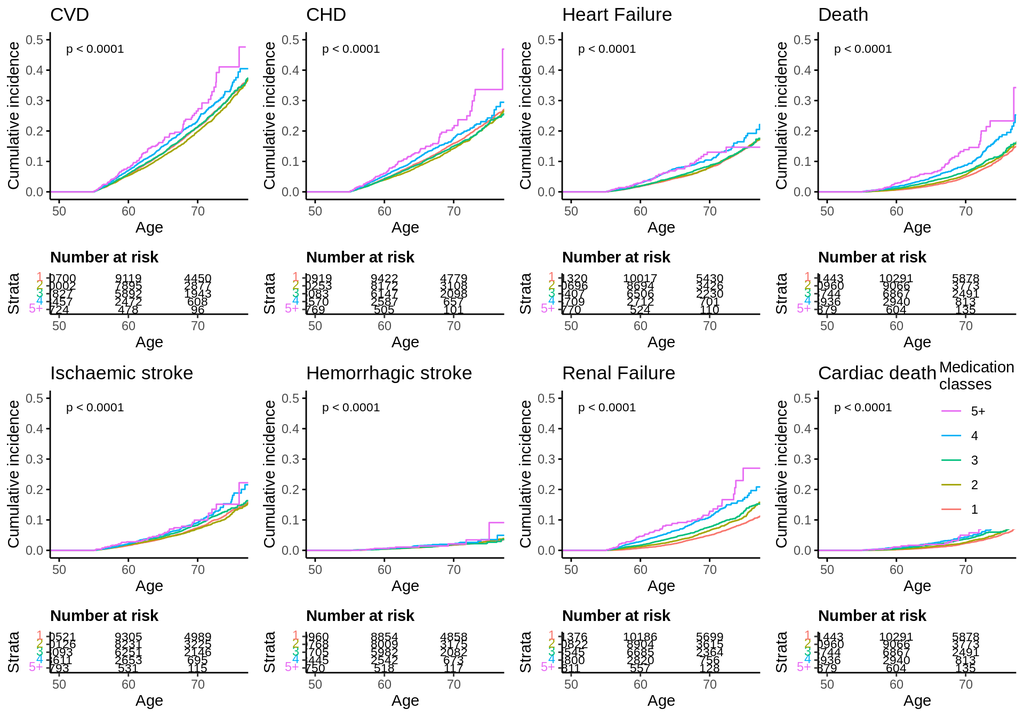

```r
legs_nr_cl <- c("1","2","3","4","5+")
names_ep_tmp <- list("CVD_HARD", "STR_EXH", "CHD", "INTRACRA", "HEARTFAIL", "RENFAIL", "DEATH", "K_CARDIAC")
ep<- names_ep_tmp[[1]]

plot_list.c <- lapply(names_ep_tmp, function(ep){
    survplot <- ggsurvplot(kms.c[[ep]], fun="event", conf.int = F, censor = F,
                           pval=T, pval.coord = c(51,0.47), pval.size=3,
                           xlim=c(50,76), ylim=c(0, 0.5), break.x.by=10,
                           xlab="Age", ylab="Cumulative incidence",
                           title = nice_names[ep],  size = 0.5, ggtheme = theme_classic(),
                           legend.labs=legs_nr_cl, legend="none",
                           risk.table=T, fontsize=3, risk.table.height=0.32)
    survplot$table <- survplot$table +
              theme(plot.title = element_text(size=11, face="bold"))
    survplot
  })  %>% setNames(names_ep_tmp)


plot_list.c$K_CARDIAC$plot <-  plot_list.c$K_CARDIAC$plot +
      theme(legend.position = c(0.8,0.7)) +
      guides(col = guide_legend(reverse = TRUE, title = 'Medication\nclasses'))


plots.c <- arrange_ggsurvplots(plot_list.c, nrow = 2, ncol = 4)
```

```r
ggsave(file = str_glue("{fig_path}/km.c.png"), plot = plots.c, height = 9, width = 12, dpi = 200)
ggsave(file = str_glue("{fig_path}/km.c.eps"), plot = plots.c, height = 9, width = 12, dpi = 200, device = cairo_ps,)
```

### 2.1.2 Resistant hypertension

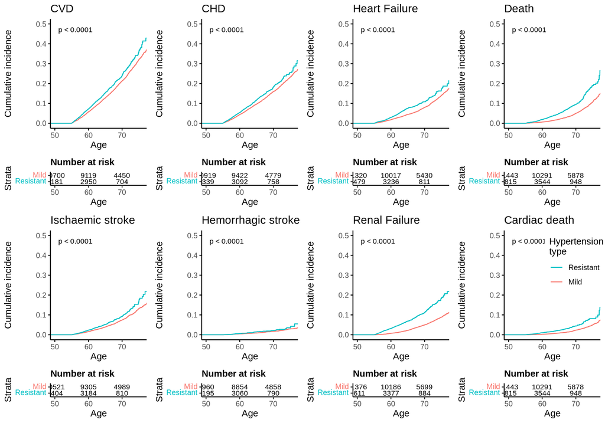

```r
legs_res_ht <- levels(df.55$RES2_HT55)

plot_list.r <- lapply(names_ep_tmp, function(ep){
    survplot <- ggsurvplot(kms.r[[ep]], fun="event", conf.int = F, censor = F,
                           pval=T, pval.coord = c(51,0.47), pval.size=3,
                           xlim=c(50,76), ylim=c(0, 0.5), break.x.by=10,
                           xlab="Age", ylab="Cumulative incidence",
                           title = nice_names[ep],  size = 0.5, ggtheme = theme_classic(),
                           legend.labs=legs_res_ht, legend="none",
                           risk.table=T, fontsize=3, risk.table.height=0.27)
    survplot$table <- survplot$table +
              theme(plot.title = element_text(size=11, face="bold"))
    survplot
  })  %>% setNames(names_ep_tmp)


plot_list.r$K_CARDIAC$plot <-  plot_list.r$K_CARDIAC$plot +
      theme(legend.position = c(0.75,0.7)) +
      guides(col = guide_legend(reverse = TRUE, title = 'Hypertension\ntype'))


plots.r <- arrange_ggsurvplots(plot_list.r, nrow = 2, ncol = 4)
```

```r
ggsave(file = str_glue("{fig_path}/km.r.png"), plot = plots.r, height = 8, width = 12, dpi = 200)
ggsave(file = str_glue("{fig_path}/km.r.eps"), plot = plots.r, height = 8, width = 12, dpi = 200, device = cairo_ps,)
```

## 2.2 Cox plots

**Cox models calculated**

```r
covs_f_pre<- paste(covs_pre, collapse = " + ")

cxs.c <-
  lapply(names_ep, function(ep){
    my_formula <- str_glue("Surv({ep}_AGE, {ep}_POST) ~ NRCL5_HT55 + {covs_f_pre}")
    coxph(as.formula(my_formula), data= df.55)
  }) %>% setNames(names_ep)

#cxs.c

df.55 <- df.55 %>% mutate_at("NRCL_HT55", as.integer)
cxs.cn <-
  lapply(names_ep, function(ep){
    my_formula <- str_glue("Surv({ep}_AGE, {ep}_POST) ~ NRCL_HT55 + {covs_f_pre}")
    coxph(as.formula(my_formula), data= df.55)
  }) %>% setNames(names_ep)


cxs.r <-
  lapply(names_ep, function(ep){
    my_formula <- str_glue("Surv({ep}_AGE, {ep}_POST) ~ RES2_HT55 + {covs_f_pre}")
    coxph(as.formula(my_formula), data= df.55)
  }) %>% setNames(names_ep)

#cxs.r
```

**Assumptions**

Assumptions are tested for ‘number of medicine classes’ as exposure.

**cloglog plot**

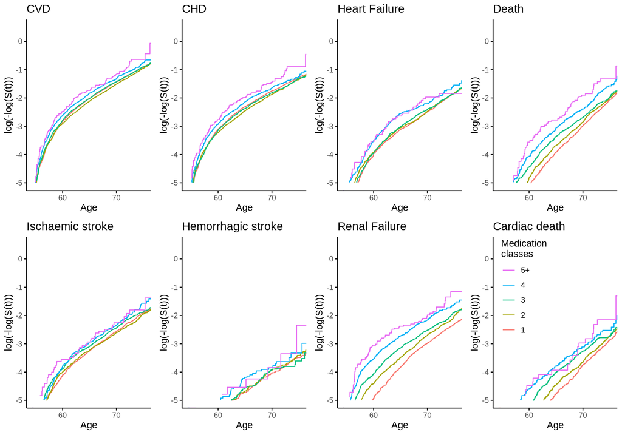

```r
plot_list.clog <- lapply(names_ep_tmp, function(ep){
    ggsurvplot(kms.c[[ep]], fun="cloglog", conf.int = F, censor = F,
                           pval.coord = c(51,0.47), pval.size=3,
                           xlim=c(55,76), ylim=c(-5,0.5),xlab="Age",
                           title = nice_names[ep],  size = 0.5, ggtheme = theme_classic(),
                           legend.labs=legs_nr_cl, legend="none")
  })  %>% setNames(names_ep_tmp)


plot_list.clog$K_CARDIAC$plot <-  plot_list.clog$K_CARDIAC$plot +
      theme(legend.position = c(0.25, 0.7)) +
      guides(col = guide_legend(reverse = TRUE, title = 'Medication\nclasses'))

plots.clog <- arrange_ggsurvplots(plot_list.clog, nrow = 2, ncol = 4)
```

```r
ggsave(file = str_glue("{fig_path}/clog.55.png"), plot = plots.clog, height = 8, width = 12, dpi = 200)
ggsave(file = str_glue("{fig_path}/clog.55.eps"), plot = plots.clog, height = 8, width = 12, dpi = 200, device = cairo_ps)
```

**Tables**

```r
removed_cols <- c("CHD.Variable", "STR_EXH.Variable", "INTRACRA.Variable", "HEARTFAIL.Variable", "RENFAIL.Variable", "DEATH.Variable", "K_CARDIAC.Variable")
#names_ep_post <- lapply(names_ep, function(ep){str_glue("{ep}_POST")})

#Number of drug classes
lapply(names_ep, function(ep){
  extr_table(cxs.c[[ep]], "NRCL") %>%
  select(-pval)
})%>% setNames(names_ep) %>%
  do.call(cbind,.)  %>%
  select(-one_of(removed_cols)) %>%
  mutate_all(as.character) %>%
  my.kable() %>%   kable_styling(font_size = font_size)
```

| CVD_HARD.Variable | CVD_HARD.HR | CHD.HR | HEARTFAIL.HR | STR_EXH.HR | INTRACRA.HR | RENFAIL.HR | DEATH.HR | K_CARDIAC.HR |
| --- | --- | --- | --- | --- | --- | --- | --- | --- |
| NRCL5_HT552 | 0.94 (0.88-1) | 0.91 (0.85-0.98) | 1.02 (0.93-1.12) | 0.95 (0.86-1.05) | 1.05 (0.84-1.3) | 1.27 (1.14-1.42) | 1.13 (1.01-1.26) | 1.15 (0.99-1.35) |
| NRCL5_HT553 | 1.03 (0.96-1.1) | 0.96 (0.88-1.04) | 1.07 (0.96-1.19) | 1.13 (1.01-1.26) | 1.01 (0.79-1.29) | 1.47 (1.31-1.66) | 1.29 (1.15-1.44) | 1.51 (1.28-1.77) |
| NRCL5_HT554 | 1.08 (0.98-1.18) | 1.04 (0.93-1.16) | 1.34 (1.17-1.54) | 1.19 (1.03-1.39) | 1.36 (0.99-1.87) | 1.98 (1.71-2.28) | 1.63 (1.41-1.89) | 1.63 (1.31-2.02) |
| NRCL5_HT555+ | 1.19 (0.99-1.44) | 1.22 (0.99-1.51) | 1.26 (0.94-1.68) | 1.19 (0.87-1.62) | 1.4 (0.74-2.67) | 2.27 (1.76-2.93) | 2.2 (1.7-2.85) | 1.69 (1.11-2.57) |

```r
#Number of drug classes/numeric
lapply(names_ep, function(ep){
  extr_table(cxs.cn[[ep]], "NRCL") %>%
  select(-pval)
})%>% setNames(names_ep) %>%
  do.call(cbind,.)  %>%
  select(-one_of(removed_cols)) %>%
  mutate_all(as.character) %>%
  my.kable() %>%   kable_styling(font_size = font_size)
```

| CVD_HARD.Variable | CVD_HARD.HR | CHD.HR | HEARTFAIL.HR | STR_EXH.HR | INTRACRA.HR | RENFAIL.HR | DEATH.HR | K_CARDIAC.HR |
| --- | --- | --- | --- | --- | --- | --- | --- | --- |
| NRCL_HT55 | 1.03 (1-1.05) | 1.01 (0.98-1.04) | 1.07 (1.03-1.11) | 1.06 (1.02-1.1) | 1.07 (0.98-1.16) | 1.23 (1.19-1.28) | 1.17 (1.13-1.22) | 1.18 (1.12-1.25) |

```r
#Resistant hypertension
lapply(names_ep, function(ep){
  extr_table(cxs.r[[ep]], "RES2_HT") %>%
  select(-pval)
})%>% setNames(names_ep) %>%
  do.call(cbind,.)  %>%
  select(-one_of(removed_cols)) %>%
  mutate_all(as.character) %>%
  my.kable() %>%   kable_styling(font_size = font_size)
```

| CVD_HARD.Variable | CVD_HARD.HR | CHD.HR | HEARTFAIL.HR | STR_EXH.HR | INTRACRA.HR | RENFAIL.HR | DEATH.HR | K_CARDIAC.HR |
| --- | --- | --- | --- | --- | --- | --- | --- | --- |
| RES2_HT55Resistant | 1.1 (1-1.2) | 1.06 (0.96-1.18) | 1.34 (1.17-1.53) | 1.23 (1.07-1.43) | 1.41 (1.04-1.92) | 2 (1.74-2.31) | 1.75 (1.52-2.02) | 1.68 (1.36-2.08) |

### 2.2.1 Number of medicine classes

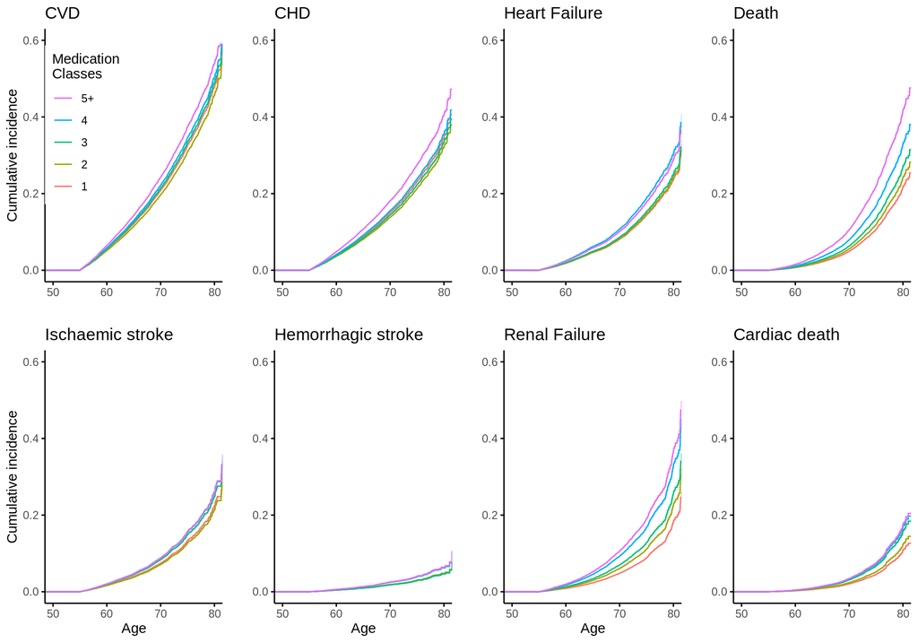

```r
names_ep_tmp <- list("CVD_HARD", "CHD","HEARTFAIL", "DEATH", "STR_EXH", "INTRACRA",  "RENFAIL",  "K_CARDIAC")

legs_nr_cl <- c("1","2","3","4","5+")
#names_ep_3 <- list("CVD_HARD","CHD", "RENFAIL")

#Covariate combinations
exp.covs <- expand.grid(
      female = 0.5,
      DIABETES_PRE = mean( df.55$DIABETES_PRE, na.rm=T),
      OBESITY_PRE = mean(df.55$OBESITY_PRE, na.rm=T),
      HYPCHOL_WIDE_PRE = mean( df.55$OBESITY_PRE, na.rm=T)
    )

fit.cxs.c <-
  lapply(names_ep_tmp, function(ep){

    exp.var <- expand.grid(NRCL5_HT55 = legs_nr_cl)
    exp.cxs <- bind_cols(exp.var, exp.covs)
    survfit(cxs.c[[ep]], newdata = exp.cxs)

  }) %>% setNames(names_ep_tmp)


plot_list.c <- lapply(names_ep_tmp, function(ep){

  ggsurvplot(fit.cxs.c[[ep]], fun="event", data= df.55, conf.int = F, censor = F, xlim=c(50,80), ylim=c(0,0.6),
             title = nice_names[[ep]],  size = 0.5, ggtheme = theme_classic(), legend.labs=legs_nr_cl,
             legend="none", break.x.by=10, xlab=" ", ylab=" ")$plot
})  %>% setNames(names_ep_tmp)

#Individual images are adjusted separately

plot_list.c$CVD_HARD <-  plot_list.c$CVD_HARD +
      ylab("Cumulative incidence") +
      theme(legend.position = c(0.23,0.62)) +
      guides(col = guide_legend(reverse = TRUE, title = 'Medication\nClasses'))

plot_list.c$STR_EXH <-  plot_list.c$STR_EXH +
  xlab("Age") + ylab("Cumulative incidence")

plot_list.c$INTRACRA <-  plot_list.c$INTRACRA +
  xlab("Age")

plot_list.c$RENFAIL <-  plot_list.c$RENFAIL +
  xlab("Age")


plots.c <- grid.arrange(grobs = plot_list.c, nrow=2, ncol = 4)
```

```r
ggsave(file = str_glue("{fig_path}/cx.medcl.55.png"), plot = plots.c, height = 6, width = 12, dpi = 300)
ggsave(file = str_glue("{fig_path}/cx.medcl.55.eps"), plot = plots.c, device = cairo_ps, height = 6, width = 12, dpi = 300)
```

### 2.2.2 Resistant hypertension

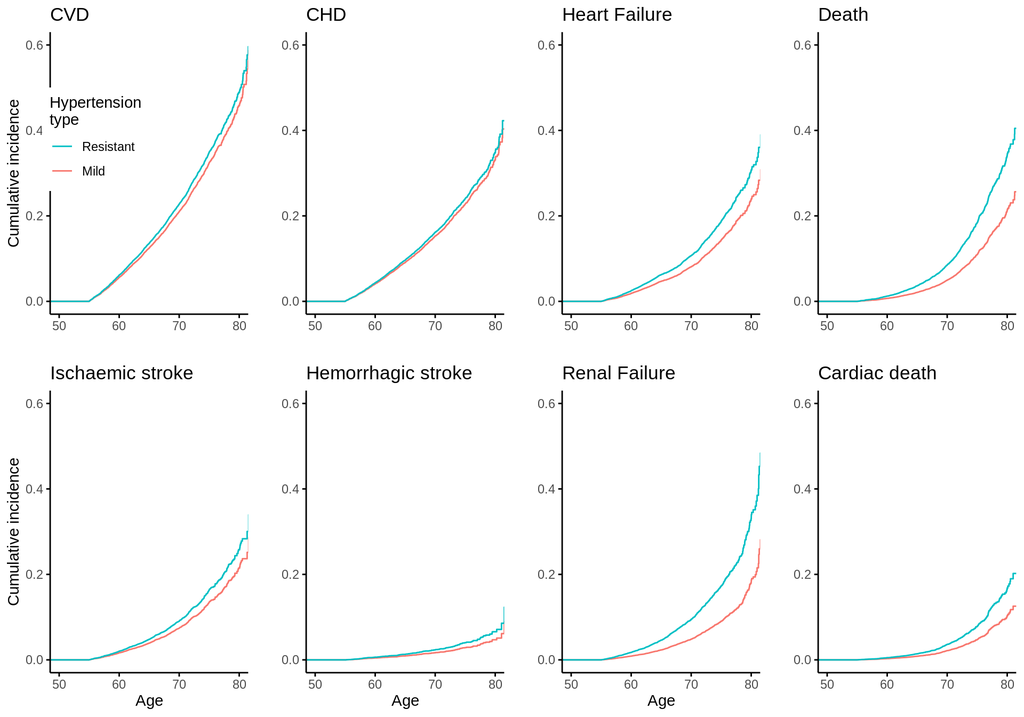

```r
fit.cxs.r <-
  lapply(names_ep_tmp, function(ep){

    exp.var <- expand.grid(RES2_HT55 = levels(as.factor( df.55$RES2_HT55)))
    exp.cxs <- bind_cols(exp.var, exp.covs)
    survfit(cxs.r[[ep]], newdata = exp.cxs)

  }) %>% setNames(names_ep_tmp)

plot_list.r <- lapply(names_ep_tmp, function(ep){

  ggsurvplot(fit.cxs.r[[ep]], fun="event", data= df.55, conf.int = F, censor = F, xlim=c(50,80), ylim=c(0,0.6),
             title = nice_names[[ep]],  size = 0.5, ggtheme = theme_classic(), legend.labs=levels( df.55$RES2_HT55),
             legend="none", break.x.by=10, xlab=" ", ylab=" ")$plot
})  %>% setNames(names_ep_tmp)

#Individual images are adjusted separately

plot_list.r$CVD_HARD <-  plot_list.r$CVD_HARD +
      ylab("Cumulative incidence") +
      theme(legend.position = c(0.23,0.62)) +
      guides(col = guide_legend(reverse = TRUE, title = 'Hypertension\ntype'))

plot_list.r$STR_EXH <-  plot_list.r$STR_EXH +
  xlab("Age") + ylab("Cumulative incidence")

plot_list.r$INTRACRA <-  plot_list.r$INTRACRA +
  xlab("Age")

plot_list.r$RENFAIL <-  plot_list.r$RENFAIL +
  xlab("Age")

plots.r <- grid.arrange(grobs = plot_list.r, nrow=2, ncol = 4)
```

```r
ggsave(file = str_glue("{fig_path}/cx.resht.55.png"), plot = plots.r, height = 6, width = 12, dpi = 300)
ggsave(file = str_glue("{fig_path}/cx.resht.55.eps"), plot = plots.r, device = cairo_ps, height = 6, width = 12, dpi = 300)
```